| title: “Brownlows Bets” |
| --- |
| author: “Corine Romero” |
| date: “October 16, 2019” |
| output: html_document: default |

# Introduction

At the first day of class there are 35 students in Math Statistics class and professor Brownlow always proposes this bet to his students “I will wager $2 to your bet of $1 that at least two people in today’s class have the same birthday. He tells me he has made that bet 1137 times so far. Where do you think his profits are? Discuss this in a markdown document

# Methods

We set up a dataset of Birthdays containing all the days of the year and then run the sample 35 times with replacement, if there is the same birthdate 2 or more times Brownlow bank goes up by $1 or if no repeats accure Brownlow Bank goes down by $2. We will repeat this 1137 times. Then we will set up a histogram with a 95% confidence with %5 in the beginning and %5 in the end.

# Profit Estimate

First we create the year data and a vector to containsamples

```r
Bdays = 1:365
Bsamples = vector('numeric')
Totaldollars = 0
Savedollars = vector ('numeric')
```

run the simulation 1137 times.

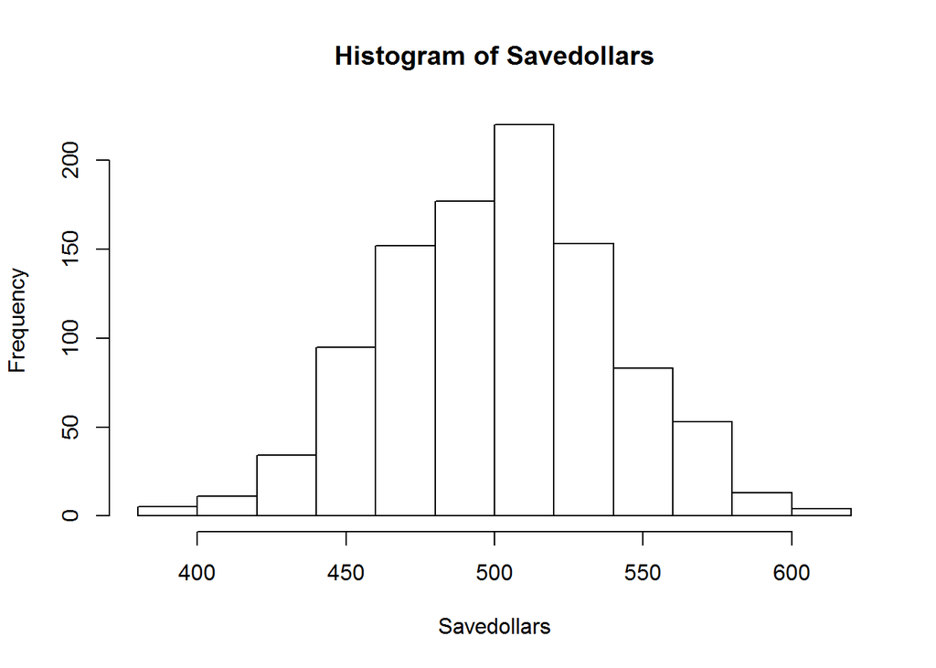

```r
for(loop in 1:1000) {

Totaldollars=0
for(i in 1:1137) {
Bsamples = sample(Bdays,35 , replace=TRUE)
if (length(unique(Bsamples)) == 35) {
  Totaldollars = Totaldollars -2
} else {
  Totaldollars = Totaldollars +1
}
}
Savedollars[loop] = Totaldollars
}
hist(Savedollars)
```

```r
print(mean(Savedollars))
```

```
## [1] 501.675
```

# Confidence interval of Brownlow’s earning

```r
stdevDollars = sd(Savedollars)
meandollars= mean(Savedollars)
CI = c(meandollars-2*stdevDollars, meandollars+2*stdevDollars)

print(CI)
```

```
## [1] 424.6763 578.6737
```

# Discussion and Conclusion

In order for Profesor Brownlow to come out even or close to even he must reduce the number of students in the class to 27 to 28 students. For him to come out exactly even he must have a 27 and a half of a student. If he wants to make more money he would have to have more than 35 students in the class and if he wanted to lose money he would make this bet with a class of less than 35 students. Does Professor Brownlow report this in his taxes?

If we change the payouts to +$1 if he wins and -$4.50 if he loses Professor Brownlow would break even.